# Module 4 - Quiz

Sasha Ajay Malkani

2025-11-25

## Question 1

When performing gene set analysis it is critical to use the same annotation as was used in pre-processing steps. Read the paper behind the Bottomly data set on the [ReCount database:](http://www.ncbi.nlm.nih.gov/pubmed?term=21455293)

Using the paper and the function: supportedGenomes() in the goseq package can you figure out which of the Mouse genome builds they aligned the reads to.

### 1. A. Installing Bioconductor package

```r
# if (!require("BiocManager", quietly = TRUE))
#   install.packages("BiocManager")
# BiocManager::install()
```

### 1. B. Installing

```r
# BiocManager::install(c("goseq"), force = TRUE)
```

### 1. C. Troubleshooting installing packages

```r
# BiocManager::valid()
```

### 1. D. Load Libraries

```r
library(goseq)
```

### 1. E. Identify the Mouse Genome the reads are align to

```r
supportedGenomes()
```

```
##          db          species       date
## 3   anoCar1           Lizard  Feb. 2007
## 5   anoGam1       A. gambiae  Feb. 2003
## 7   apiMel1     A. mellifera  July 2004
## 8   apiMel2     A. mellifera  Jan. 2005
## 9   aplCal1         Sea hare Sept. 2008
## 14  bosTau2              Cow  Mar. 2005
## 15  bosTau3              Cow  Aug. 2006
## 16  bosTau4              Cow  Oct. 2007
## 21  braFlo1         Lancelet  Mar. 2006
## 22  caeJap1      C. japonica  Mar. 2008
## 23   caePb1      C. brenneri  Jan. 2007
## 24   caePb2      C. brenneri  Feb. 2008
## 25  caeRem2       C. remanei  Mar. 2006
## 26  caeRem3       C. remanei   May 2007
```

[output cut: 243 more lines]

- **UCSC mm9**
- UCSC hg18
- NCBI Build 35
- UCSC hg19

## Question 2

Load the Bottomly data with the following code and perform a differential expression analysis using limma with only the strain variable as an outcome. How many genes are differentially expressed at the 5% FDR level using Benjamini-Hochberg correction? What is the gene identifier of the first gene differentially expressed at this level (just in order, not the smallest FDR)? (hint: the featureNames function may be useful)

### 2. A. Load Libraries

```r
library(Biobase)
library(limma)
```

### 2. B. Load Data

```r
con =url("http://bowtie-bio.sourceforge.net/recount/ExpressionSets/bottomly_eset.RData")
load(file=con)
close(con)
ls()
```

```
## [1] "bottomly.eset" "con"
```

```r
bot = bottomly.eset
bot
```

```
## ExpressionSet (storageMode: lockedEnvironment)
## assayData: 36536 features, 21 samples
##   element names: exprs
## protocolData: none
## phenoData
##   sampleNames: SRX033480 SRX033488 ... SRX033494 (21 total)
##   varLabels: sample.id num.tech.reps ... lane.number (5 total)
##   varMetadata: labelDescription
## featureData
##   featureNames: ENSMUSG00000000001 ENSMUSG00000000003 ...
##     ENSMUSG00000090268 (36536 total)
##   fvarLabels: gene
##   fvarMetadata: labelDescription
## experimentData: use 'experimentData(object)'
## Annotation:
```

```r
pdata_bot=pData(bot)
head(pdata_bot)
```

```
##           sample.id num.tech.reps   strain experiment.number lane.number
## SRX033480 SRX033480             1 C57BL/6J                 6           1
## SRX033488 SRX033488             1 C57BL/6J                 7           1
## SRX033481 SRX033481             1 C57BL/6J                 6           2
## SRX033489 SRX033489             1 C57BL/6J                 7           2
## SRX033482 SRX033482             1 C57BL/6J                 6           3
## SRX033490 SRX033490             1 C57BL/6J                 7           3
```

```r
fdata_bot = featureData(bot)
head(fdata_bot)
```

```
## An object of class 'AnnotatedDataFrame'
##   featureNames: ENSMUSG00000000001 ENSMUSG00000000003 ...
##     ENSMUSG00000000049 (6 total)
##   varLabels: gene
##   varMetadata: labelDescription
```

```r
edata = exprs(bot)
head(edata)
```

```
##                    SRX033480 SRX033488 SRX033481 SRX033489 SRX033482 SRX033490
## ENSMUSG00000000001       369       744       287       769       348       803
## ENSMUSG00000000003         0         0         0         0         0         0
## ENSMUSG00000000028         0         1         0         1         1         1
## ENSMUSG00000000031         0         0         0         0         0         0
## ENSMUSG00000000037         0         1         1         5         0         4
## ENSMUSG00000000049         0         1         0         1         0         0
##                    SRX033483 SRX033476 SRX033478 SRX033479 SRX033472 SRX033473
## ENSMUSG00000000001       433       469       585       321       301       461
## ENSMUSG00000000003         0         0         0         0         0         0
## ENSMUSG00000000028         0         7         6         1         1         1
## ENSMUSG00000000031         0         0         0         0         0         0
## ENSMUSG00000000037         0         0         0         0         4         1
## ENSMUSG00000000049         0         0         0         0         0         0
##                    SRX033474 SRX033475 SRX033491 SRX033484 SRX033492 SRX033485
## ENSMUSG00000000001       309       374       781       555       820       294
## ENSMUSG00000000003         0         0         0         0         0         0
## ENSMUSG00000000028         1         1         1         2         1         1
## ENSMUSG00000000031         0         0         0         0         0         0
## ENSMUSG00000000037         1         0         1         2         1         1
## ENSMUSG00000000049         0         0         0         0         0         0
##                    SRX033493 SRX033486 SRX033494
## ENSMUSG00000000001       758       419       857
## ENSMUSG00000000003         0         0         0
## ENSMUSG00000000028         4         1         5
## ENSMUSG00000000031         0         0         0
## ENSMUSG00000000037         1         1         2
## ENSMUSG00000000049         0         0         0
```

### 2. C. Remove lowly expressed genes and Log2 transform the data

```r
fdata_bot = fdata_bot[rowMeans(edata) > 5]
head(fdata_bot)
```

```
## An object of class 'AnnotatedDataFrame'
##   featureNames: ENSMUSG00000000001 ENSMUSG00000000056 ...
##     ENSMUSG00000000093 (6 total)
##   varLabels: gene
##   varMetadata: labelDescription
```

```r
edata = edata[rowMeans(edata) > 5, ]
edata = log2(edata+1)
head(edata)
```

```
##                    SRX033480 SRX033488 SRX033481 SRX033489 SRX033482 SRX033490
## ENSMUSG00000000001  8.531381  9.541097  8.169925  9.588715  8.447083  9.651052
## ENSMUSG00000000056  4.459432  5.554589  4.392317  5.209453  3.700440  5.807355
## ENSMUSG00000000058  4.000000  5.459432  3.700440  5.129283  3.906891  5.044394
## ENSMUSG00000000078  9.016808  9.773139  8.413628  9.668885  8.566054  9.749869
## ENSMUSG00000000088  8.098032  9.611025  8.108524  9.543032  8.238405  9.353147
## ENSMUSG00000000093  3.584963  4.643856  3.807355  5.129283  4.807355  5.357552
##                    SRX033483 SRX033476 SRX033478 SRX033479 SRX033472 SRX033473
## ENSMUSG00000000001  8.761551  8.876517  9.194757  8.330917  8.238405  8.851749
## ENSMUSG00000000056  4.807355  5.491853  5.044394  5.584963  5.357552  5.357552
## ENSMUSG00000000058  4.321928  4.247928  5.491853  4.523562  4.169925  4.643856
## ENSMUSG00000000078  9.047124  8.651052  9.192293  8.651052  8.375039  8.754888
## ENSMUSG00000000088  8.515700  8.696968  8.829723  8.375039  8.888743  9.100662
## ENSMUSG00000000093  4.169925  5.643856  5.584963  5.209453  4.857981  5.000000
##                    SRX033474 SRX033475 SRX033491 SRX033484 SRX033492 SRX033485
## ENSMUSG00000000001  8.276124  8.550747  9.611025  9.118941  9.681238  8.204571
## ENSMUSG00000000056  4.954196  4.807355  5.554589  4.857981  5.357552  4.459432
## ENSMUSG00000000058  4.906891  4.000000  5.129283  4.584963  5.285402  4.169925
## ENSMUSG00000000078  8.417853  8.909893  9.862637  9.194757 10.152285  8.939579
## ENSMUSG00000000088  8.693487  8.629357 10.172428  9.779719  9.748193  8.754888
## ENSMUSG00000000093  4.584963  4.392317  5.209453  4.000000  5.285402  5.209453
##                    SRX033493 SRX033486 SRX033494
## ENSMUSG00000000001  9.567956  8.714246  9.744834
## ENSMUSG00000000056  5.727920  4.807355  5.523562
## ENSMUSG00000000058  4.906891  3.700440  4.857981
## ENSMUSG00000000078 10.076816  9.144658  9.505812
## ENSMUSG00000000088  9.829723  9.211888  9.980140
## ENSMUSG00000000093  5.000000  3.459432  5.169925
```

### 2. D. Perform a differential expression analysis using limma

```r
mod = model.matrix(~ pdata_bot$strain)
fit_limma = lmFit(edata, mod)
ebayes_limma = eBayes(fit_limma)
limma_pvals = topTable(ebayes_limma,number=dim(edata)[1], adjust.method ="BH", p.value=0.05, sort.by='none')
```

```
## Removing intercept from test coefficients
```

### 2. E. First DE gene

```r
limma_pvals[1,]
```

```
##                        logFC  AveExpr         t      P.Value   adj.P.Val
## ENSMUSG00000000402 -1.222062 4.292471 -4.509076 5.312399e-05 0.004394846
##                           B
## ENSMUSG00000000402 1.583059
```

### 2. F. Number of genes are differentially expressed at the 5% FPR level

```r
dim(limma_pvals)
```

```
## [1] 223   6
```

- 9431 at FDR 5%; ENSMUSG00000027855 first DE gene
- **223 at FDR 5%; ENSMUSG00000000402 first DE gene**
- 223 at FDR 5%; ENSMUSG00000027855 first DE gene
- 90 at FDR 5%; ENSMUSG00000000001 first DE gene

## Question 3

Use the nullp and goseq functions in the goseq package to perform a gene ontology analysis. What is the top category that comes up as over represented? (hint: you will need to use the genome information on the genome from question 1 and the differential expression analysis from question 2)

### 3. A. Load Libraries

```r
library(devtools)
library(Biobase)
library(goseq)
library(DESeq2)
```

### 3. B. Limma fit with p-value less than 0.05

```r
limma_table = topTable(ebayes_limma,number=dim(edata)[1], adjust.method ="BH", sort.by='none')
```

```
## Removing intercept from test coefficients
```

```r
genes = as.integer(limma_table$adj.P.Val < 0.05)
names(genes) = rownames(edata)
not_na = !is.na(genes)
genes = genes[not_na]
```

### 3. C. Use nullp and goseq to perform a gene ontology analysis

```r
pwf = nullp(genes, "mm9", "ensGene")
```

```
## Loading mm9 length data...
```

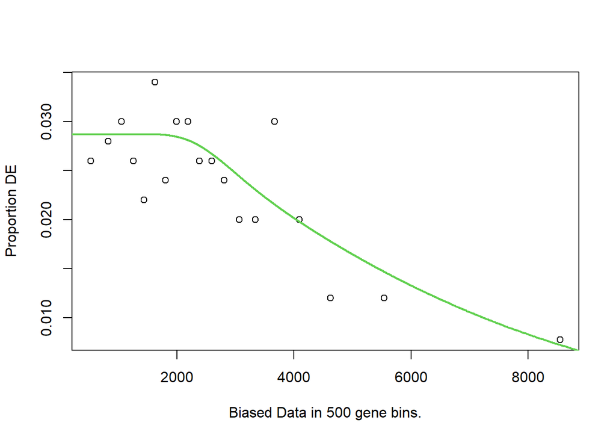

### 3. D. Gene Annotation

```r
library(org.Mm.eg.db)
GO.wall = goseq(pwf, "mm9", "ensGene")
```

```
## Fetching GO annotations...
```

```
## For 545 genes, we could not find any categories. These genes will be excluded.
```

```
## To force their use, please run with use_genes_without_cat=TRUE (see documentation).
```

```
## This was the default behavior for version 1.15.1 and earlier.
```

```
## Calculating the p-values...
```

```r
GO.top10 = GO.wall[1:10,1]
```

### 3. E. Top category

```r
GO.top10[1]
```

```
## [1] "GO:0004888"
```

- GO:0043231
- **GO:0004888**
- GO:0038023
- GO:0001653

## Question 4

Look up the GO category that was the top category from the previous question. What is the name of the category?

### 4. A. Top term

```r
GO.wall$term[1]
```

```
## [1] "transmembrane signaling receptor activity"
```

- G-protein coupled peptide receptor activity
- peptide receptor activity
- signaling receptor activity
- **transmembrane signaling receptor activity**

## Question 5

Load the Bottomly data with the following code and perform a differential expression analysis using limma and treating strain as the outcome but adjusting for lane as a factor. Then find genes significant at the 5% FDR rate using the Benjamini Hochberg correction and perform the gene set analysis with goseq following the protocol from the first 4 questions. How many of the top 10 overrepresented categories are the same for the adjusted and unadjusted analysis?

### 5. A. Load Libraries

```r
library(Biobase)
library(limma)
```

### 5. B. Load Data

```r
con =url("http://bowtie-bio.sourceforge.net/recount/ExpressionSets/bottomly_eset.RData")
load(file=con)
close(con)
ls()
```

```
##  [1] "bot"                "bottomly.eset"      "con"
##  [4] "ebayes_limma"       "edata"              "fdata_bot"
##  [7] "fit_limma"          "genes"              "GO.top10"
## [10] "GO.wall"            "limma_pvals"        "limma_table"
## [13] "mm9.ensGene.LENGTH" "mod"                "not_na"
## [16] "pdata_bot"          "pwf"
```

```r
bot = bottomly.eset
bot
```

```
## ExpressionSet (storageMode: lockedEnvironment)
## assayData: 36536 features, 21 samples
##   element names: exprs
## protocolData: none
## phenoData
##   sampleNames: SRX033480 SRX033488 ... SRX033494 (21 total)
##   varLabels: sample.id num.tech.reps ... lane.number (5 total)
##   varMetadata: labelDescription
## featureData
##   featureNames: ENSMUSG00000000001 ENSMUSG00000000003 ...
##     ENSMUSG00000090268 (36536 total)
##   fvarLabels: gene
##   fvarMetadata: labelDescription
## experimentData: use 'experimentData(object)'
## Annotation:
```

```r
pdata_bot=pData(bot)
head(pdata_bot)
```

```
##           sample.id num.tech.reps   strain experiment.number lane.number
## SRX033480 SRX033480             1 C57BL/6J                 6           1
## SRX033488 SRX033488             1 C57BL/6J                 7           1
## SRX033481 SRX033481             1 C57BL/6J                 6           2
## SRX033489 SRX033489             1 C57BL/6J                 7           2
## SRX033482 SRX033482             1 C57BL/6J                 6           3
## SRX033490 SRX033490             1 C57BL/6J                 7           3
```

```r
fdata_bot = featureData(bot)
head(fdata_bot)
```

```
## An object of class 'AnnotatedDataFrame'
##   featureNames: ENSMUSG00000000001 ENSMUSG00000000003 ...
##     ENSMUSG00000000049 (6 total)
##   varLabels: gene
##   varMetadata: labelDescription
```

```r
edata = exprs(bot)
head(edata)
```

```
##                    SRX033480 SRX033488 SRX033481 SRX033489 SRX033482 SRX033490
## ENSMUSG00000000001       369       744       287       769       348       803
## ENSMUSG00000000003         0         0         0         0         0         0
## ENSMUSG00000000028         0         1         0         1         1         1
## ENSMUSG00000000031         0         0         0         0         0         0
## ENSMUSG00000000037         0         1         1         5         0         4
## ENSMUSG00000000049         0         1         0         1         0         0
##                    SRX033483 SRX033476 SRX033478 SRX033479 SRX033472 SRX033473
## ENSMUSG00000000001       433       469       585       321       301       461
## ENSMUSG00000000003         0         0         0         0         0         0
## ENSMUSG00000000028         0         7         6         1         1         1
## ENSMUSG00000000031         0         0         0         0         0         0
## ENSMUSG00000000037         0         0         0         0         4         1
## ENSMUSG00000000049         0         0         0         0         0         0
##                    SRX033474 SRX033475 SRX033491 SRX033484 SRX033492 SRX033485
## ENSMUSG00000000001       309       374       781       555       820       294
## ENSMUSG00000000003         0         0         0         0         0         0
## ENSMUSG00000000028         1         1         1         2         1         1
## ENSMUSG00000000031         0         0         0         0         0         0
## ENSMUSG00000000037         1         0         1         2         1         1
## ENSMUSG00000000049         0         0         0         0         0         0
##                    SRX033493 SRX033486 SRX033494
## ENSMUSG00000000001       758       419       857
## ENSMUSG00000000003         0         0         0
## ENSMUSG00000000028         4         1         5
## ENSMUSG00000000031         0         0         0
## ENSMUSG00000000037         1         1         2
## ENSMUSG00000000049         0         0         0
```

```r
fdata_bot = fdata_bot[rowMeans(edata) > 5]
head(fdata_bot)
```

```
## An object of class 'AnnotatedDataFrame'
##   featureNames: ENSMUSG00000000001 ENSMUSG00000000056 ...
##     ENSMUSG00000000093 (6 total)
##   varLabels: gene
##   varMetadata: labelDescription
```

```r
edata = edata[rowMeans(edata) > 5, ]
head(edata)
```

```
##                    SRX033480 SRX033488 SRX033481 SRX033489 SRX033482 SRX033490
## ENSMUSG00000000001       369       744       287       769       348       803
## ENSMUSG00000000056        21        46        20        36        12        55
## ENSMUSG00000000058        15        43        12        34        14        32
## ENSMUSG00000000078       517       874       340       813       378       860
## ENSMUSG00000000088       273       781       275       745       301       653
## ENSMUSG00000000093        11        24        13        34        27        40
##                    SRX033483 SRX033476 SRX033478 SRX033479 SRX033472 SRX033473
## ENSMUSG00000000001       433       469       585       321       301       461
## ENSMUSG00000000056        27        44        32        47        40        40
## ENSMUSG00000000058        19        18        44        22        17        24
## ENSMUSG00000000078       528       401       584       401       331       431
## ENSMUSG00000000088       365       414       454       331       473       548
## ENSMUSG00000000093        17        49        47        36        28        31
##                    SRX033474 SRX033475 SRX033491 SRX033484 SRX033492 SRX033485
## ENSMUSG00000000001       309       374       781       555       820       294
## ENSMUSG00000000056        30        27        46        28        40        21
## ENSMUSG00000000058        29        15        34        23        38        17
## ENSMUSG00000000078       341       480       930       585      1137       490
## ENSMUSG00000000088       413       395      1153       878       859       431
## ENSMUSG00000000093        23        20        36        15        38        36
##                    SRX033493 SRX033486 SRX033494
## ENSMUSG00000000001       758       419       857
## ENSMUSG00000000056        52        27        45
## ENSMUSG00000000058        29        12        28
## ENSMUSG00000000078      1079       565       726
## ENSMUSG00000000088       909       592      1009
## ENSMUSG00000000093        31        10        35
```

### 5. C. Perform a differential expression analysis using limma, unadjusted for lane

```r
mod_unadj = model.matrix(~ pdata_bot$strain)
fit_limma_unadj = lmFit(edata,mod_unadj)
ebayes_limma_unadj = eBayes(fit_limma_unadj)
```

### 5. D. Perform a differential expression analysis using limma, adjusting for lane as a factor

```r
mod_adj = model.matrix(~ pdata_bot$strain + as.factor(pdata_bot$lane.number))
fit_limma_adj = lmFit(edata,mod_adj)
ebayes_limma_adj = eBayes(fit_limma_adj)
```

### 5. E. Find genes significant at 5% FPR rate (unadjusted model)

```r
limma_table_unadj = topTable(ebayes_limma_unadj, number=dim(edata)[1], adjust.method ="BH", sort.by='none')
```

```
## Removing intercept from test coefficients
```

```r
genes_unadj = as.integer(limma_table_unadj$adj.P.Val < 0.05)
names(genes_unadj) = rownames(edata)
not_na = !is.na(genes_unadj)
genes_unadj = genes_unadj[not_na]
pwf_unadj = nullp(genes_unadj, "mm9", "ensGene")
```

```
## Loading mm9 length data...
```

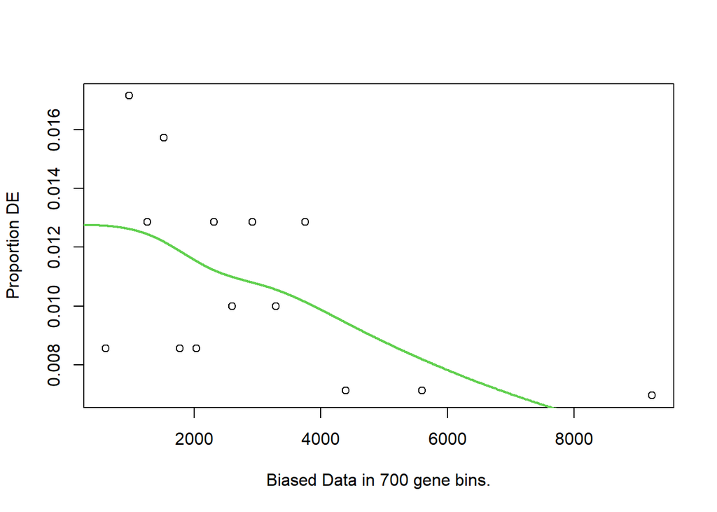

### 5. F. Find genes significant at 5% FPR rate (adjusted model)

```r
limma_table_adj = topTable(ebayes_limma_adj, number=dim(edata)[1], adjust.method ="BH", sort.by='none')
```

```
## Removing intercept from test coefficients
```

```r
genes_adj = as.integer(limma_table_adj$adj.P.Val < 0.05)
names(genes_adj) = rownames(edata)
not_na = !is.na(genes_adj)
genes_adj = genes_adj[not_na]
pwf_adj = nullp(genes_adj, "mm9", "ensGene")
```

```
## Loading mm9 length data...
```

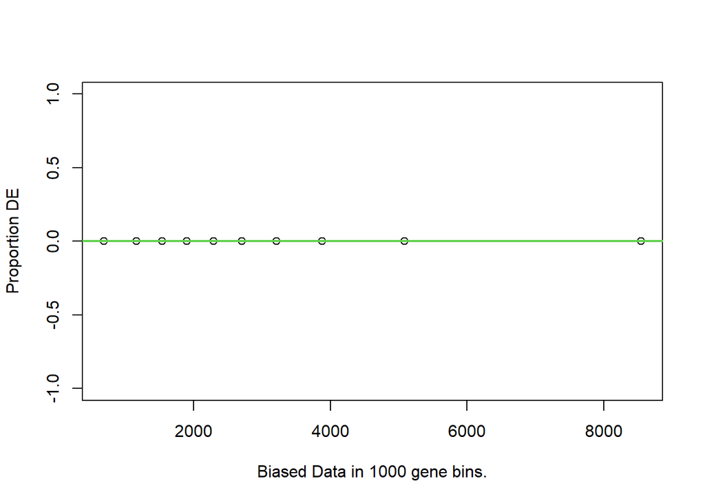

## 5. G. Annotation

```r
GO.wall_adj = goseq(pwf_adj, "mm9", "ensGene")
```

```
## Fetching GO annotations...
```

```
## For 545 genes, we could not find any categories. These genes will be excluded.
```

```
## To force their use, please run with use_genes_without_cat=TRUE (see documentation).
```

```
## This was the default behavior for version 1.15.1 and earlier.
```

```
## Calculating the p-values...
```

```r
GO.top10_adj = GO.wall_adj[1:10,1]
GO.wall_unadj = goseq(pwf_unadj, "mm9", "ensGene")
```

```
## Fetching GO annotations...
```

```
## For 545 genes, we could not find any categories. These genes will be excluded.
```

```
## To force their use, please run with use_genes_without_cat=TRUE (see documentation).
```

```
## This was the default behavior for version 1.15.1 and earlier.
```

```
## Calculating the p-values...
```

```r
GO.top10_unadj = GO.wall_unadj[1:10,1]
```

## 5. H. Top 10 overrepresented categories are the same

```r
GO.wall_results = cbind(GO.top10_unadj, GO.top10_adj)
GO.wall_results
```

```
##       GO.top10_unadj GO.top10_adj
##  [1,] "GO:0007129"   "GO:0000009"
##  [2,] "GO:0070192"   "GO:0000012"
##  [3,] "GO:0007127"   "GO:0000014"
##  [4,] "GO:0045143"   "GO:0000015"
##  [5,] "GO:0061982"   "GO:0000018"
##  [6,] "GO:0030849"   "GO:0000019"
##  [7,] "GO:0051026"   "GO:0000022"
##  [8,] "GO:1903046"   "GO:0000026"
##  [9,] "GO:0045132"   "GO:0000027"
## [10,] "GO:0047198"   "GO:0000028"
```

```r
intersect(GO.top10_unadj, GO.top10_adj)
```

```
## character(0)
```

```r
Sys.Date()
```

```
## [1] "2025-11-26"
```